# Final project

Yi-Hsuan Lo

2022-12-31

#### Data was downloaded at “Systematic global assessment of reef fish communities by the Reef Life Survey program”: “IMOS - National Reef Monitoring Network Sub-Facility - Global reef fish abundance and biomass” in .csv format, then, I took data from 2021/01/01 to 2021/12/31 in the ecoregion of “Central and Southern Great Barrier Reef” as my data subset.

#### The problems I want to investigate are (1) What is the species diversity of reef fish in the region of Great Barrier Reef and what is their community structure (e.g., species composition). (2) Is there differences in fish abundance and biomass between different locations in this ecoregion. (3) Is there a linear relationship between fish abundance and fish biomass.

### **Load package**

```r
library(tidyverse)
library(raster)
library(MASS)
```

#### After deleting annotations above the data frame, I loaded it into R studio like below:

#### I then deleted some columns that I thought it wouldn’t be used in my analysis

### **Load data**

```r
setwd("C:\\Users\\user\\Desktop")
globalfish <- read.csv("global_fish.csv")
fish <- globalfish[,-c(1,3:6,14,17:19,26,30)] %>% separate("survey_date",c("year","month","date"))
str(fish)
```

```
## 'data.frame':    6086 obs. of  21 variables:
##  $ survey_id   : int  912354477 912354477 912354477 912354477 912354477 912354477 912354477 912354477 912354477 912354477 ...
##  $ location    : chr  "QLD inshore - South" "QLD inshore - South" "QLD inshore - South" "QLD inshore - South" ...
##  $ site_code   : chr  "GBR142" "GBR142" "GBR142" "GBR142" ...
##  $ site_name   : chr  "Cataren Bay" "Cataren Bay" "Cataren Bay" "Cataren Bay" ...
##  $ latitude    : num  -20.2 -20.2 -20.2 -20.2 -20.2 ...
##  $ longitude   : num  149 149 149 149 149 ...
##  $ year        : chr  "2021" "2021" "2021" "2021" ...
##  $ month       : chr  "1" "1" "1" "1" ...
##  $ date        : chr  "3" "3" "3" "3" ...
##  $ depth       : num  2.5 2.5 2.5 2.5 2.5 2.5 2.5 2.5 2.5 2.5 ...
##  $ visibility  : int  3 3 3 3 3 3 3 3 3 3 ...
##  $ hour        : chr  "11:00:00" "11:00:00" "11:00:00" "11:00:00" ...
##  $ block       : int  2 2 2 2 2 2 2 2 2 2 ...
##  $ phylum      : chr  "Chordata" "Chordata" "Chordata" "Chordata" ...
##  $ class       : chr  "Actinopterygii" "Actinopterygii" "Actinopterygii" "Actinopterygii" ...
##  $ order       : chr  "Perciformes" "Perciformes" "Perciformes" "Perciformes" ...
##  $ family      : chr  "Serranidae" "Scaridae" "Scaridae" "Scaridae" ...
##  $ species_name: chr  "Cephalopholis boenak" "Scarus rivulatus" "Scarus ghobban" "Chlorurus sordidus" ...
##  $ size_class  : num  7.5 5 2.5 2.5 5 5 7.5 5 2.5 5 ...
##  $ total       : int  1 15 8 1 2 1 21 41 21 8 ...
##  $ biomass     : num  11.097 64.739 2.845 0.634 8.718 ...
```

### **Merge site_names with same long.,lat.**

#### I found there are 4 different locations in my data so I separated them into new 4 subsets, and denoted “QLD inshore - South” as “QLD_south” (QS), “QLD inshore - Central” as “QLD_central” (QC), “GBR - South” as “GBR_south” (GS), “GBR - Central” as “GBR_central” (GC)

### **Subset data with locations**

```r
unique(fish$location)
```

```
## [1] "QLD inshore - South"   "QLD inshore - Central" "GBR - Central"
## [4] "GBR - South"
```

```r
QLD_south <- subset(fish,location=="QLD inshore - South")
QLD_central <- subset(fish,location=="QLD inshore - Central")
GBR_south <- subset(fish,location=="GBR - South")
GBR_central <- subset(fish,location=="GBR - Central")
```

#### I first plot the study locations and found QC & QS are two separated locations while GC & GS are more like a transect. Therefore, in problem (2) and (3), I only took QC and QS two sites into account

### **Plot study locations**

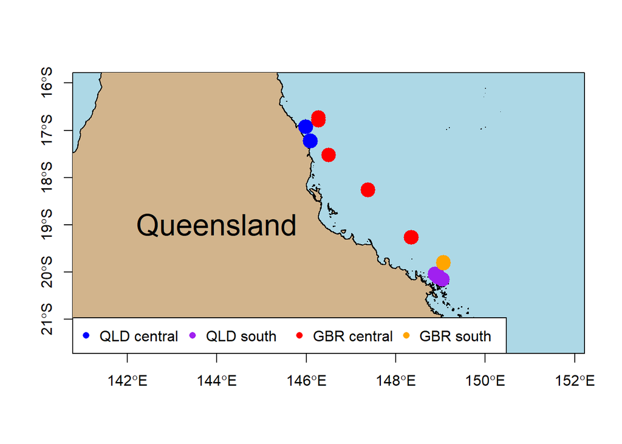

```r
AUS0 <- getData('GADM',country="AUS",level=0)
AUS1 <- getData('GADM',country="AUS",level=1)
Queensland <- AUS1[AUS1$NAME_1=="Queensland",]
plot(AUS0,axes=T,bg="lightblue",col="grey",xlim=c(144,149),ylim=c(-21.5,-16))
plot(Queensland,axes=T,bg="lightblue",col="#D2B48C",add=TRUE)

#coordinates of sites & plot
coord_QLDS <- unique(cbind(QLD_south$site_name,QLD_south$longitude,QLD_south$latitude))
coord_QLDC <- unique(cbind(QLD_central$site_name,QLD_central$longitude,QLD_central$latitude))
coord_GBRS <- unique(cbind(GBR_south$site_name,GBR_south$longitude,GBR_south$latitude))
coord_GBRC <- unique(cbind(GBR_central$site_name,GBR_central$longitude,GBR_central$latitude))
coords <- rbind(coord_QLDS,coord_QLDC,coord_GBRS,coord_GBRC)
points(coord_QLDS[,2:3],type="p",pch=16,cex=2.3,col="purple")
points(coord_QLDC[,2:3],type="p",pch=16,cex=2.3,col="blue")
points(coord_GBRS[,2:3],type="p",pch=16,cex=2.3,col="orange")
points(coord_GBRC[,2:3],type="p",pch=16,cex=2.3,col="red")
text(x=144,y=-19,"Queensland",cex=2)
legend("bottomleft",c("QLD central","QLD south","GBR central","GBR south"),col=c("blue","purple","red","orange"),pch=16,horiz=TRUE)
```

#### I use tapply to help me calculate fish abundance and biomass in the groups of every species

### **Calculate abundance & biomass in each location**

```r
#species counts (How many times the species was observed)
QS_s <- tapply(QLD_south$total,QLD_south$species,length)
QC_s <- tapply(QLD_central$total,QLD_central$species,length)
GS_s <- tapply(GBR_south$total,GBR_south$species,length)
GC_s <- tapply(GBR_central$total,GBR_central$species,length)

#species abundance
QS_a <- tapply(QLD_south$total,QLD_south$species,sum)
QC_a <- tapply(QLD_central$total,QLD_central$species,sum)
GS_a <- tapply(GBR_south$total,GBR_south$species,sum)
GC_a <- tapply(GBR_central$total,GBR_central$species,sum)

#species biomass
QS_b <- tapply(QLD_south$biomass,QLD_south$species,sum)
QC_b <- tapply(QLD_central$biomass,QLD_central$species,sum)
GS_b <- tapply(GBR_south$biomass,GBR_south$species,sum)
GC_b <- tapply(GBR_central$biomass,GBR_central$species,sum)

#total abundance
QS_ta <- sum(QLD_south$total)
QC_ta <- sum(QLD_central$total)
GS_ta <- sum(GBR_south$total)
GC_ta <- sum(GBR_central$total)

#total biomass
QS_tb <- sum(QLD_south$biomass,na.rm=T)
QC_tb <- sum(QLD_central$biomass,na.rm=T)
GS_tb <- sum(GBR_south$biomass,na.rm=T)
GC_tb <- sum(GBR_central$biomass,na.rm=T)

#relative abundance
r.abundance.QS <- tapply(QLD_south$total,QLD_south$species,sum)/sum(QLD_south$total)*100
r.abundance.QC <- tapply(QLD_central$total,QLD_central$species,sum)/sum(QLD_central$total)*100
r.abundance.GS <- tapply(GBR_south$total,GBR_south$species,sum)/sum(GBR_south$total)*100
r.abundance.GC <- tapply(GBR_central$total,GBR_central$species,sum)/sum(GBR_central$total)*100

#relative biomass from dominant to rare
r.biomass.QS <- tapply(QLD_south$biomass,QLD_south$species,sum)/sum(QLD_south$biomass,na.rm=T)*100
r.biomass.QC <- tapply(QLD_central$biomass,QLD_central$species,sum)/sum(QLD_central$biomass,na.rm=T)*100
r.biomass.GS <- tapply(GBR_south$biomass,GBR_south$species,sum)/sum(GBR_south$biomass,na.rm=T)*100
r.biomass.GC <- tapply(GBR_central$biomass,GBR_central$species,sum)/sum(GBR_central$biomass,na.rm=T)*100
```

#### Result of previous calculations:

### **Make a data frame of each location**

```r
QS <- data.frame(counts=QS_s,abundance=QS_a,total_abn=QS_ta,relative.abn=r.abundance.QS,
                  biomass=QS_b,total_bim=QS_tb,relative.bim=r.biomass.QS)
head(QS)
```

```
##                             counts abundance total_abn relative.abn    biomass
## Abudefduf bengalensis           19        55     13604   0.40429286  2672.9121
## Abudefduf sexfasciatus          15        56     13604   0.41164363  1822.9743
## Abudefduf vaigiensis             6        10     13604   0.07350779   692.4096
## Abudefduf whitleyi              13        69     13604   0.50720376  2114.7814
## Acanthochromis polyacanthus     44       766     13604   5.63069685 12287.3362
## Acanthurus grammoptilus          9        22     13604   0.16171714 11819.2347
##                             total_bim relative.bim
## Abudefduf bengalensis        345409.6    0.7738385
## Abudefduf sexfasciatus       345409.6    0.5277718
## Abudefduf vaigiensis         345409.6    0.2004605
## Abudefduf whitleyi           345409.6    0.6122533
## Acanthochromis polyacanthus  345409.6    3.5573238
## Acanthurus grammoptilus      345409.6    3.4218031
```

```r
QC <- data.frame(counts=QC_s,abundance=QC_a,total_abn=QC_ta,relative.abn=r.abundance.QC,
                  biomass=QC_b,total_bim=QC_tb,relative.bim=r.biomass.QC)
head(QC)
```

```
##                             counts abundance total_abn relative.abn    biomass
## Abudefduf bengalensis            1         1      8988   0.01112595    81.8255
## Abudefduf sexfasciatus           3        23      8988   0.25589675   439.8706
## Abudefduf vaigiensis             2         5      8988   0.05562973   164.7118
## Abudefduf whitleyi               5        21      8988   0.23364486  1182.2521
## Acanthochromis polyacanthus     46      1665      8988  18.52469960 18919.5794
## Acanthuridae spp.                2         3      8988   0.03337784    29.2798
##                             total_bim relative.bim
## Abudefduf bengalensis        167207.4   0.04893654
## Abudefduf sexfasciatus       167207.4   0.26306893
## Abudefduf vaigiensis         167207.4   0.09850751
## Abudefduf whitleyi           167207.4   0.70705748
## Acanthochromis polyacanthus  167207.4  11.31504027
## Acanthuridae spp.            167207.4   0.01751107
```

```r
GS <- data.frame(counts=GS_s,abundance=GS_a,total_abn=GS_ta,relative.abn=r.abundance.GS,
                  biomass=GS_b,total_bim=GS_tb,relative.bim=r.biomass.GS)
head(GS)
```

```
##                             counts abundance total_abn relative.abn    biomass
## Abudefduf vaigiensis             3        30      6896   0.43503480  1451.7250
## Abudefduf whitleyi               8       104      6896   1.50812065  4263.4691
## Acanthochromis polyacanthus     16       449      6896   6.51102088 10078.2854
## Acanthurus grammoptilus          2         3      6896   0.04350348  1248.0855
## Acanthurus lineatus              2         4      6896   0.05800464   935.3480
## Acanthurus nigricauda            1         1      6896   0.01450116   441.5311
##                             total_bim relative.bim
## Abudefduf vaigiensis         265528.2    0.5467310
## Abudefduf whitleyi           265528.2    1.6056558
## Acanthochromis polyacanthus  265528.2    3.7955611
## Acanthurus grammoptilus      265528.2    0.4700388
## Acanthurus lineatus          265528.2    0.3522594
## Acanthurus nigricauda        265528.2    0.1662841
```

```r
GC <- data.frame(counts=GC_s,abundance=GC_a,total_abn=GC_ta,relative.abn=r.abundance.GC,
                  biomass=GC_b,total_bim=GC_tb,relative.bim=r.biomass.GC)
head(GC)
```

```
##                             counts abundance total_abn relative.abn    biomass
## Abudefduf sexfasciatus          11        79     34699  0.227672267  4651.7035
## Abudefduf vaigiensis             1         3     34699  0.008645782   135.8786
## Abudefduf whitleyi               2        17     34699  0.048992766  1989.1252
## Acanthochromis polyacanthus     63       685     34699  1.974120292 11161.9818
## Acanthurus auranticavus          9        70     34699  0.201734920 34648.8463
## Acanthurus blochii               4        12     34699  0.034583129  4992.3422
##                             total_bim relative.bim
## Abudefduf sexfasciatus        1099601   0.42303540
## Abudefduf vaigiensis          1099601   0.01235708
## Abudefduf whitleyi            1099601   0.18089510
## Acanthochromis polyacanthus   1099601   1.01509339
## Acanthurus auranticavus       1099601   3.15103674
## Acanthurus blochii            1099601   0.45401378
```

#### Make a list of sites:

### **Site list**

```r
site.list <- list("QS"=QS,"QC"=QC,"GS"=GS,"GC"=GC)
site <- c("QS","QC","GS","GC")
```

## Question1

#### Separate species with its abundance to understand the community structure in this ecoregion

### **Species assemblage in each location, filter follow ref.1**

```r
#separate species structure with relative abundance
dominant <- NULL
for(i in 1:4){
  dominant[[i]] <- site.list[[i]] %>% filter(relative.abn>1)
}
frequent <- NULL
for(i in 1:4){
  frequent[[i]] <- site.list[[i]] %>% filter(relative.abn>=0.1 & relative.abn<1)
}
common <- NULL
for(i in 1:4){
  common[[i]] <- site.list[[i]] %>% filter(relative.abn>=0.01 & relative.abn<0.1)
}
rare <- NULL
for(i in 1:4){
  rare[[i]] <- site.list[[i]] %>% filter(relative.abn<0.01)
}
```

### **Bar plot and list of top 10 species in each structure level**

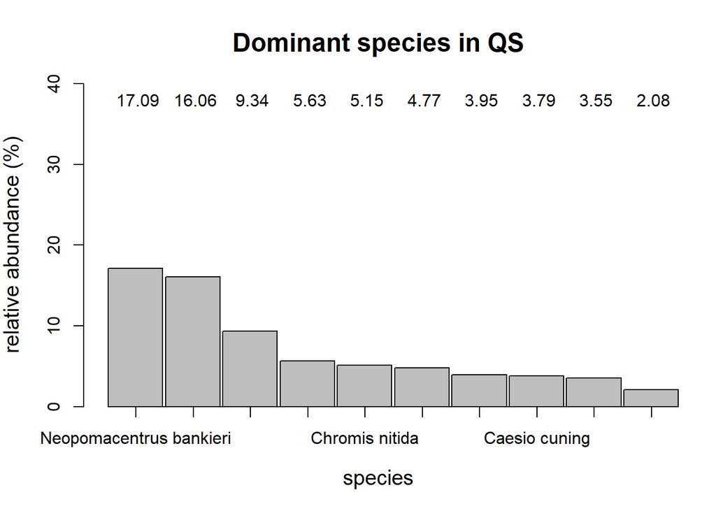

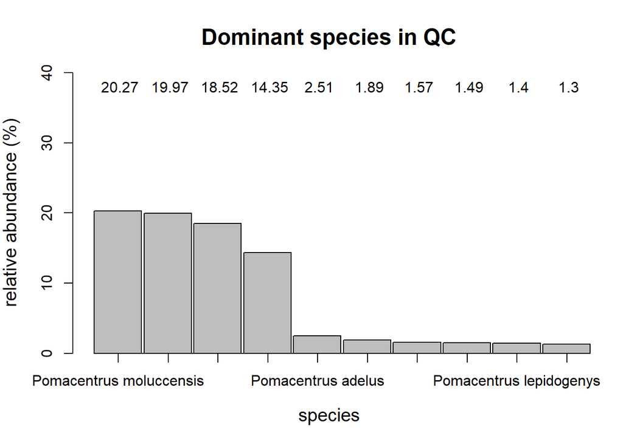

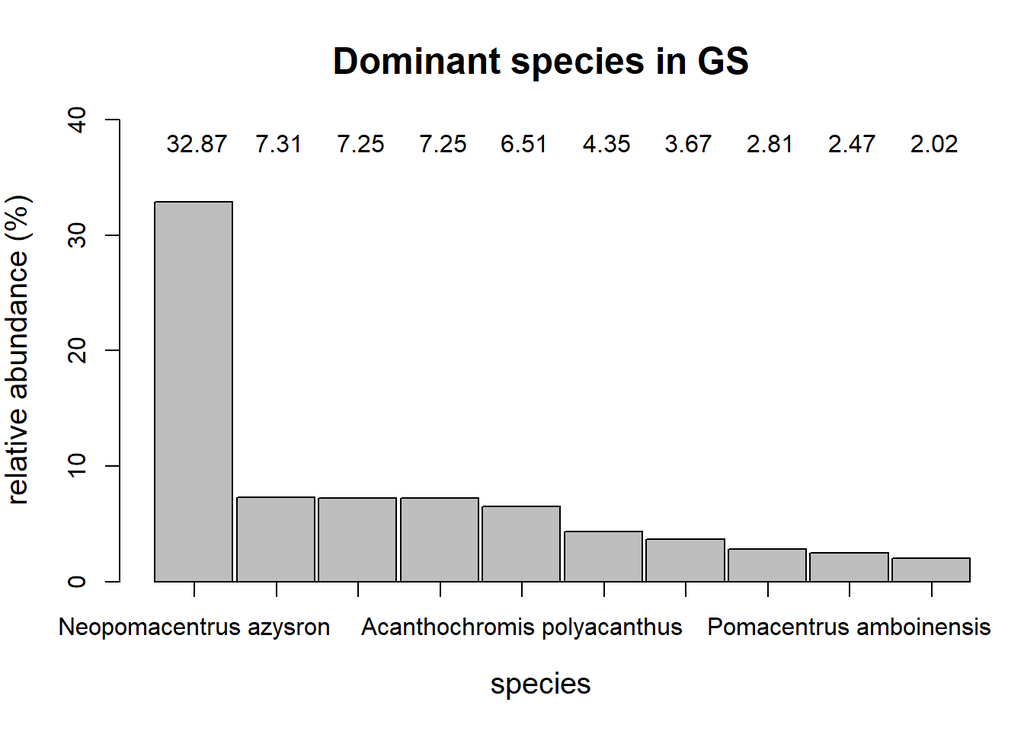

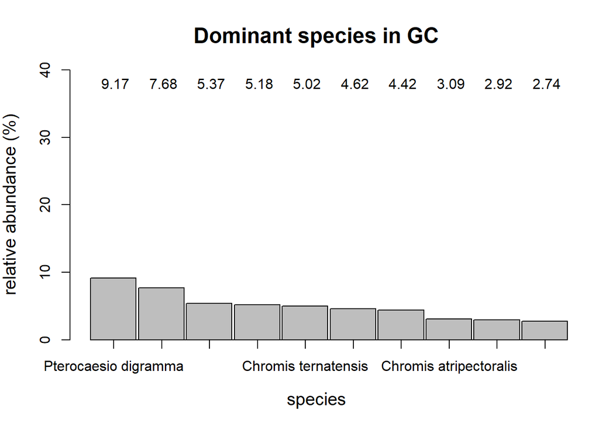

```r
#dominant species
sp.d <- matrix(0,nrow=10,ncol=4)
row <- NULL
for(i in 1:4){
  row[[i]] <- head(order(dominant[[i]][,4],decreasing=T),10)
  barplot(dominant[[i]][row[[i]],][,4],xlim=c(0,10),ylim=c(0,40),main=paste("Dominant species in",site[i]),space=0.05,xlab="species",ylab="relative abundance (%)",cex.lab=1.25,cex.main=1.5)
  axis(1,seq(0.56,length.out=10,by=1.05),rownames(dominant[[i]][row[[i]],]),cex=1)
  text(x=seq(0.6,length.out=10,by=1.05),y=38,labels=round(dominant[[i]][row[[i]],][,4],2))
  sp.d[,i] <- c(rownames(dominant[[i]][row[[i]],]))
  }
```

```r
colnames(sp.d) <- site
head(sp.d,10)
```

```
##       QS                            QC
##  [1,] "Neopomacentrus bankieri"     "Pomacentrus moluccensis"
##  [2,] "Aioliops novaeguineae"       "Pomacentrus wardi"
##  [3,] "Pomacentrus wardi"           "Acanthochromis polyacanthus"
##  [4,] "Acanthochromis polyacanthus" "Neopomacentrus azysron"
##  [5,] "Chromis nitida"              "Pomacentrus adelus"
##  [6,] "Neopomacentrus azysron"      "Halichoeres melanurus"
##  [7,] "Pomacentrus moluccensis"     "Neopomacentrus bankieri"
##  [8,] "Caesio cuning"               "Pomacentrus brachialis"
##  [9,] "Thalassoma lunare"           "Pomacentrus lepidogenys"
## [10,] "Cirrhilabrus punctatus"      "Stegastes apicalis"
##       GS                            GC
##  [1,] "Neopomacentrus azysron"      "Pterocaesio digramma"
##  [2,] "Cirrhilabrus punctatus"      "Neopomacentrus azysron"
##  [3,] "Caesio cuning"               "Pomacentrus moluccensis"
##  [4,] "Pomacentrus lepidogenys"     "Cirrhilabrus punctatus"
##  [5,] "Acanthochromis polyacanthus" "Chromis ternatensis"
##  [6,] "Pomacentrus imitator"        "Pomacentrus brachialis"
##  [7,] "Chromis nitida"              "Pomacentrus lepidogenys"
##  [8,] "Pomacentrus coelestis"       "Chromis atripectoralis"
##  [9,] "Pomacentrus amboinensis"     "Cheilodipterus quinquelineatus"
## [10,] "Pomacentrus moluccensis"     "Aioliops novaeguineae"
```

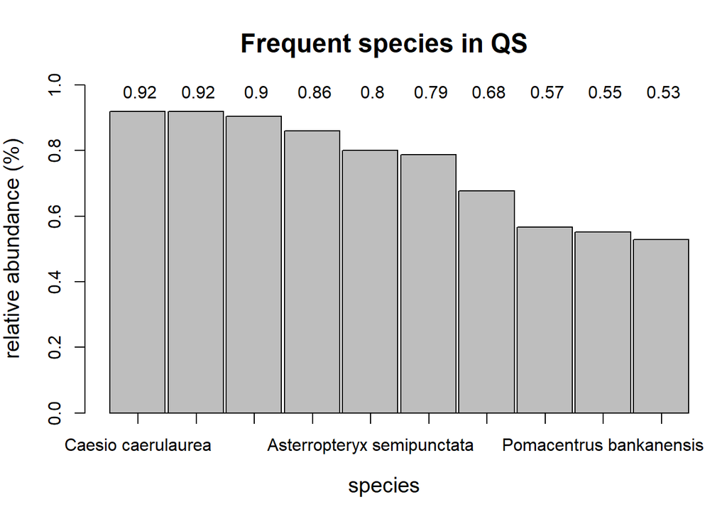

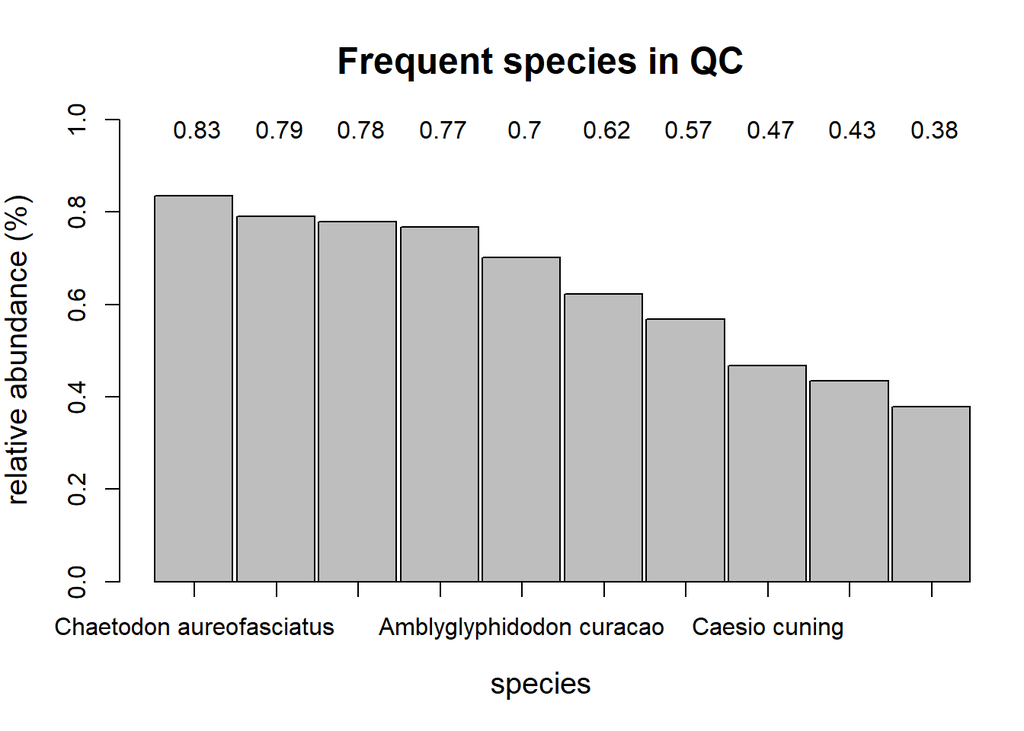

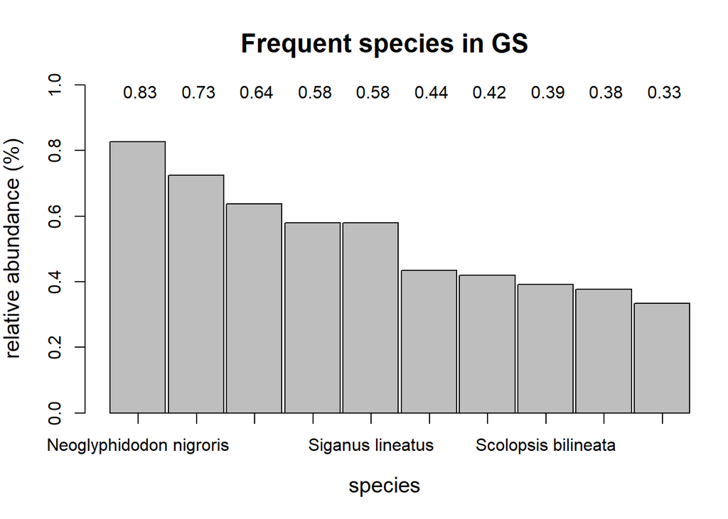

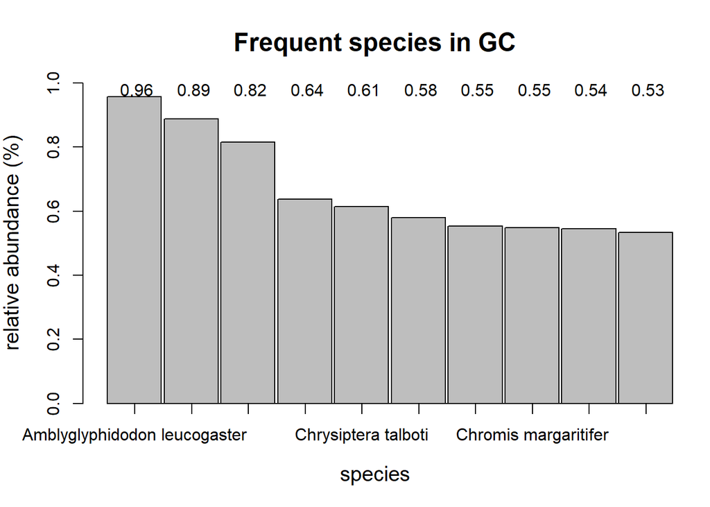

```r
#frequent species
sp.f <- matrix(0,nrow=10,ncol=4)
row <- NULL
for(i in 1:4){
  row[[i]] <- head(order(frequent[[i]][,4],decreasing=T),10)
  barplot(frequent[[i]][row[[i]],][,4],xlim=c(0,10),ylim=c(0,1),main=paste("Frequent species in",site[i]),space=0.05,xlab="species",ylab="relative abundance (%)",cex.lab=1.25,cex.main=1.5)
  axis(1,seq(0.56,length.out=10,by=1.05),rownames(frequent[[i]][row[[i]],]),cex=1)
  text(x=seq(0.6,length.out=10,by=1.05),y=0.98,labels=round(frequent[[i]][row[[i]],][,4],2))
  sp.f[,i] <- c(rownames(frequent[[i]][row[[i]],]))
}
```

```r
colnames(sp.f) <- site
head(sp.f,10)
```

```
##       QS                               QC
##  [1,] "Caesio caerulaurea"             "Chaetodon aureofasciatus"
##  [2,] "Scarus rivulatus"               "Labroides dimidiatus"
##  [3,] "Pomacentrus amboinensis"        "Chromis ternatensis"
##  [4,] "Pomacentrus lepidogenys"        "Pomacentrus coelestis"
##  [5,] "Asterropteryx semipunctata"     "Amblyglyphidodon curacao"
##  [6,] "Amblygobius phalaena"           "Coris batuensis"
##  [7,] "Cheilodipterus quinquelineatus" "Thalassoma lunare"
##  [8,] "Scolopsis bilineata"            "Caesio cuning"
##  [9,] "Pomacentrus bankanensis"        "Hemigymnus melapterus"
## [10,] "Stegastes apicalis"             "Siganus doliatus"
##       GS                        GC
##  [1,] "Neoglyphidodon nigroris" "Amblyglyphidodon leucogaster"
##  [2,] "Aioliops novaeguineae"   "Chromis viridis"
##  [3,] "Halichoeres melanurus"   "Ctenochaetus striatus"
##  [4,] "Lutjanus carponotatus"   "Chromis iomelas"
##  [5,] "Siganus lineatus"        "Chrysiptera talboti"
##  [6,] "Abudefduf vaigiensis"    "Bryaninops natans"
##  [7,] "Scarus schlegeli"        "Halichoeres melanurus"
##  [8,] "Scolopsis bilineata"     "Chromis margaritifer"
##  [9,] "Labroides dimidiatus"    "Thalassoma lunare"
## [10,] "Siganus doliatus"        "Dascyllus aruanus"
```

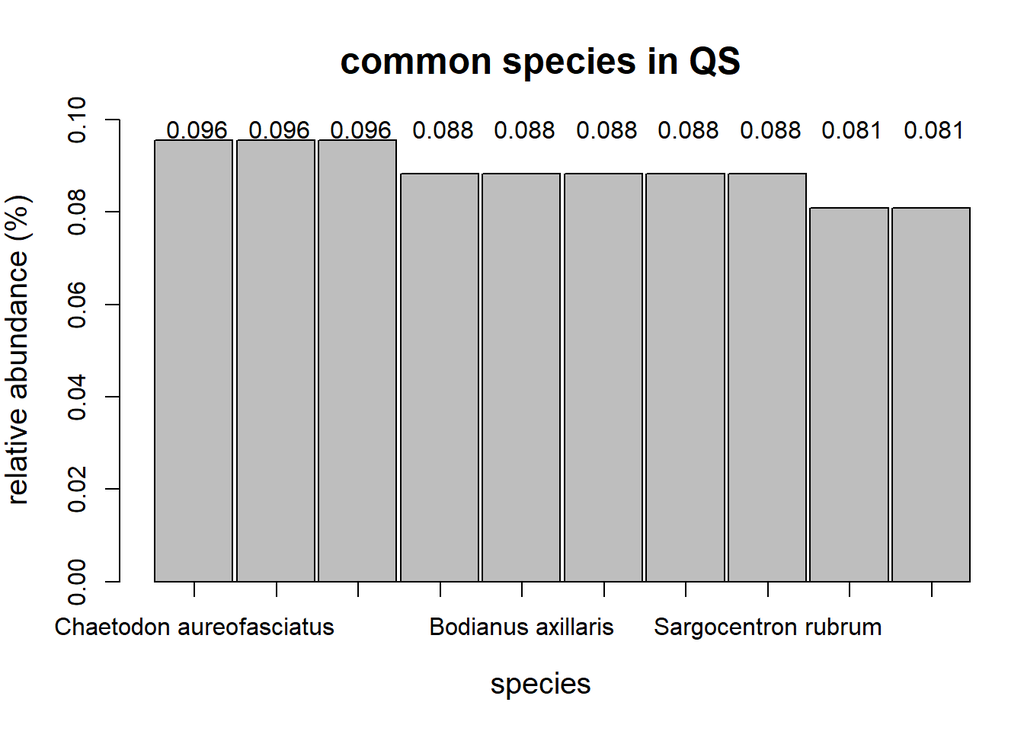

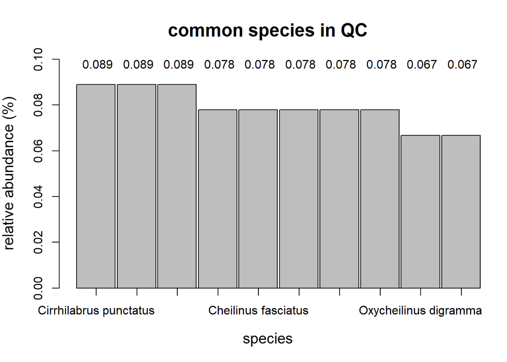

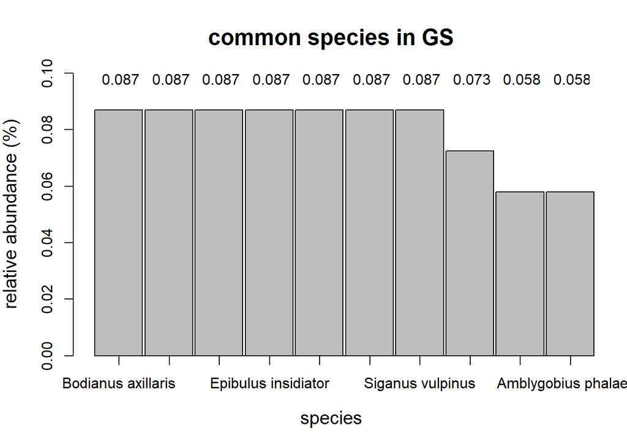

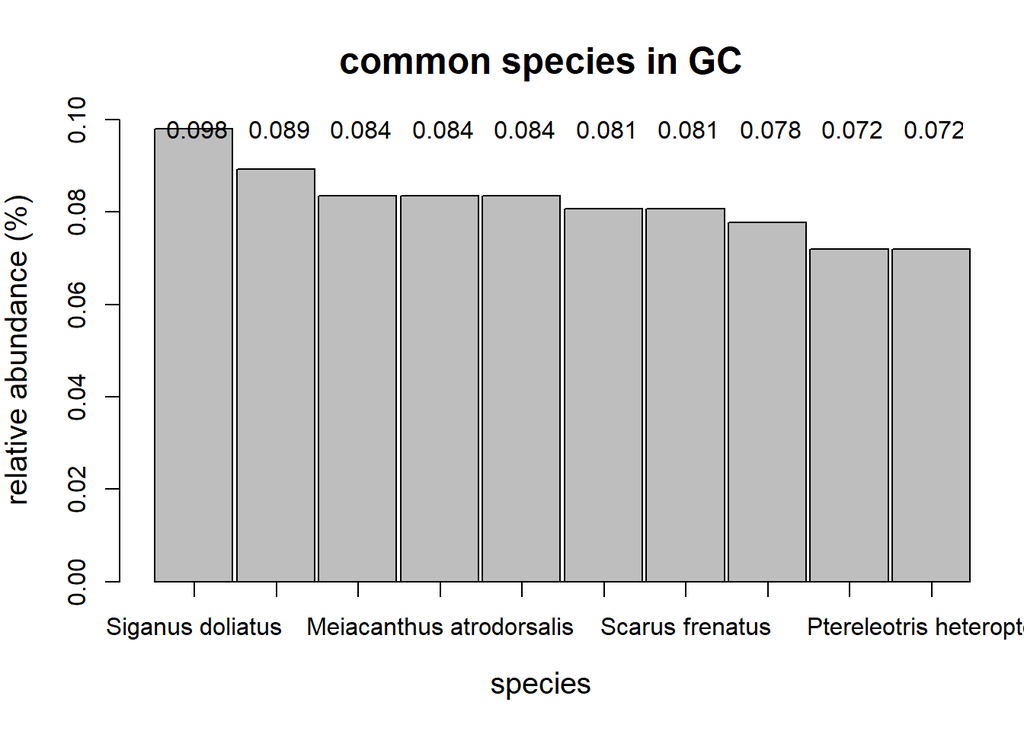

```r
#common species
sp.c <- matrix(0,nrow=10,ncol=4)
row <- NULL
for(i in 1:4){
  row[[i]] <- head(order(common[[i]][,4],decreasing=T),10)
  barplot(common[[i]][row[[i]],][,4],xlim=c(0,10),ylim=c(0,0.1),main=paste("common species in",site[i]),space=0.05,xlab="species",ylab="relative abundance (%)",cex.lab=1.25,cex.main=1.5)
  axis(1,seq(0.56,length.out=10,by=1.05),rownames(common[[i]][row[[i]],]),cex=1)
  text(x=seq(0.6,length.out=10,by=1.05),y=0.098,labels=round(common[[i]][row[[i]],][,4],3))
  sp.c[,i] <- c(rownames(common[[i]][row[[i]],]))
}
```

```r
colnames(sp.c) <- site
head(sp.c,10)
```

```
##       QS                             QC
##  [1,] "Chaetodon aureofasciatus"     "Cirrhilabrus punctatus"
##  [2,] "Hemigymnus melapterus"        "Dascyllus reticulatus"
##  [3,] "Pomacentrus sp. [rhodonotus]" "Hemiglyphidodon plagiometopon"
##  [4,] "Amblygobius nocturnus"        "Chaetodon melannotus"
##  [5,] "Bodianus axillaris"           "Cheilinus fasciatus"
##  [6,] "Cheilinus fasciatus"          "Halichoeres marginatus"
##  [7,] "Pempheris analis"             "Halichoeres nebulosus"
##  [8,] "Sargocentron rubrum"          "Pomacentrus amboinensis"
##  [9,] "Amblyglyphidodon leucogaster" "Oxycheilinus digramma"
## [10,] "Cheilinus chlorourus"         "Pseudocheilinus hexataenia"
##       GS                        GC
##  [1,] "Bodianus axillaris"      "Siganus doliatus"
##  [2,] "Chelmon rostratus"       "Pomacentrus adelus"
##  [3,] "Diploprion bifasciatum"  "Cheilinus fasciatus"
##  [4,] "Epibulus insidiator"     "Meiacanthus atrodorsalis"
##  [5,] "Hemigymnus fasciatus"    "Oxycheilinus digramma"
##  [6,] "Scolopsis margaritifer"  "Chaetodon plebeius"
##  [7,] "Siganus vulpinus"        "Scarus frenatus"
##  [8,] "Chrysiptera brownriggii" "Paracirrhites arcatus"
##  [9,] "Acanthurus lineatus"     "Acanthurus lineatus"
## [10,] "Amblygobius phalaena"    "Ptereleotris heteroptera"
```

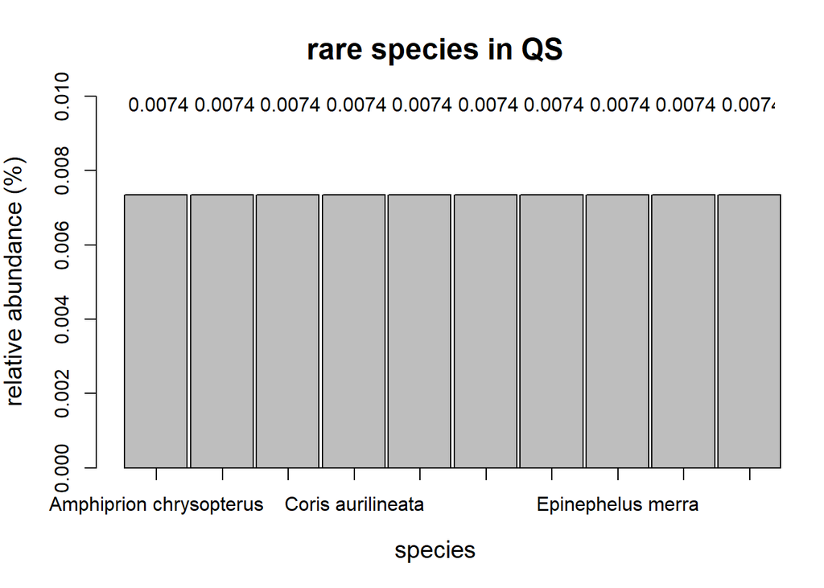

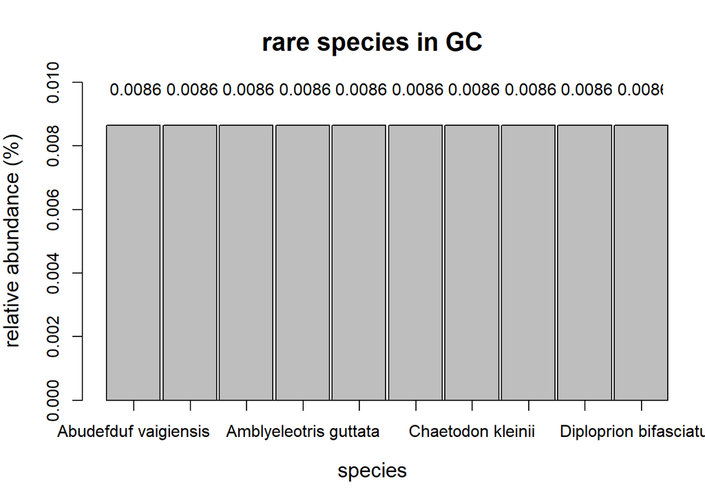

```r
#rare species
sp.r <- matrix(0,nrow=10,ncol=4)
row <- NULL
for(i in c(1,4)){
  row[[i]] <- head(order(rare[[i]][,4],decreasing=T),10)
  barplot(rare[[i]][row[[i]],][,4],xlim=c(0,10),ylim=c(0,0.01),main=paste("rare species in",site[i]),space=0.05,xlab="species",ylab="relative abundance (%)",cex.lab=1.25,cex.main=1.5)
  axis(1,seq(0.56,length.out=10,by=1.05),rownames(rare[[i]][row[[i]],]),cex=1)
  text(x=seq(0.6,length.out=10,by=1.05),y=0.0098,labels=round(rare[[i]][row[[i]],][,4],4))
  sp.r[,i] <- c(rownames(rare[[i]][row[[i]],]))
}
```

```r
colnames(sp.r) <- site
head(sp.r,10)
```

```
##       QS                          QC  GS  GC
##  [1,] "Amphiprion chrysopterus"   "0" "0" "Abudefduf vaigiensis"
##  [2,] "Chaetodon baronessa"       "0" "0" "Acanthurus dussumieri"
##  [3,] "Cirripectes chelomatus"    "0" "0" "Acanthurus xanthopterus"
##  [4,] "Coris aurilineata"         "0" "0" "Amblyeleotris guttata"
##  [5,] "Ecsenius stictus"          "0" "0" "Amphiprion melanopus"
##  [6,] "Epinephelus coioides"      "0" "0" "Bodianus mesothorax"
##  [7,] "Epinephelus fuscoguttatus" "0" "0" "Chaetodon kleinii"
##  [8,] "Epinephelus merra"         "0" "0" "Chaetodon lineolatus"
##  [9,] "Eucrossorhinus dasypogon"  "0" "0" "Chromis nitida"
## [10,] "Eviota spp."               "0" "0" "Diploprion bifasciatum"
```

### **Calculate alpha diversity in each location**

```r
#merge data frames with species names
QS$species <- rownames(QS)
QC$species <- rownames(QC)
GS$species <- rownames(GS)
GC$species <- rownames(GC)
a <- full_join(QS,QC,by="species")
b <- full_join(GS,GC,by="species")
c <- full_join(a,b,by="species")

#abundance of every species in each location
data.abd <- c[,c(8,2,10,17,24)]
colnames(data.abd) <- c("species",site)
#biomass of every species in each location
data.bim <- c[,c(8,5,13,20,27)]
colnames(data.bim) <- c("species",site)

#Species Richness:
richness <- c()
for(i in 1:4){
  richness[i] <- length(which(data.abd[,i+1]>0))
}

#Shannon index: H = -1*sum(propotion(species)*log(propotion(species)))
total.abd <- c()
propotions <- list()
log.prop <- list()
multiply.ln <- list()
sum.mul <- c()
shannon <- c()
for(i in 1:4){
  total.abd[i] <- sum(which(data.abd[,i+1]>0))
  propotions[[i]] <- data.abd[which(data.abd[,i+1]>0),i+1]/total.abd[i]
  log.prop[[i]] <- log(propotions[[i]])
  multiply.ln[[i]] <- propotions[[i]]*log.prop[[i]]
  sum.mul[i] <- sum(multiply.ln[[i]])
  shannon[i] <- sum.mul[i]*-1
}

#Species evenness: H/log(richness)
evenness <- c()
for(i in 1:4){
  evenness[i] <- shannon[i]/log(richness[i])
}

#dataframe
alpha.div <- data.frame(richness,shannon,evenness)
rownames(alpha.div) <- site
alpha.div
```

```
##    richness  shannon  evenness
## QS      169 3.123888 0.6089571
## QC      124 1.791771 0.3717150
## GS      109 1.713273 0.3651985
## GC      273 2.736098 0.4877639
```

#### As we can see, community in location GC has the highest species richness but only with the second highest shannon diversity and evenness. Instead, community in location QS with the highest shannon diversity and evenness appears to be the strongest community in these 4 locations.

## Question 2

#### Abundance and biomass in QS & QC are not normally distributed, therefore, I use non-parameter Wilcoxon test to test whether there differences in abundance and biomass between these two locations.

### **T test of abundance and biomass in QS & QC**

```r
#data frame
abd.t.test <- data.abd[which(data.abd[,2]>0&data.abd[,3]>0),2:3]
bim.t.test <- data.bim[which(data.bim[,2]>0&data.bim[,3]>0),2:3]

#shapiro test to check normality
#abundance and biomass do not follow normal distribution
apply(abd.t.test,2,shapiro.test)
```

```
## $QS
##
##  Shapiro-Wilk normality test
##
## data:  newX[, i]
## W = 0.44506, p-value = 4.943e-15
##
##
## $QC
##
##  Shapiro-Wilk normality test
##
## data:  newX[, i]
## W = 0.32619, p-value < 2.2e-16
```

```r
apply(bim.t.test,2,shapiro.test)
```

```
## $QS
##
##  Shapiro-Wilk normality test
##
## data:  newX[, i]
## W = 0.40642, p-value = 2.54e-15
##
##
## $QC
##
##  Shapiro-Wilk normality test
##
## data:  newX[, i]
## W = 0.36789, p-value = 8.484e-16
```

```r
#Wilcoxon test
wilcox.test(abd.t.test$QS,abd.t.test$QC)
```

```
##
##  Wilcoxon rank sum test with continuity correction
##
## data:  abd.t.test$QS and abd.t.test$QC
## W = 3178, p-value = 0.01911
## alternative hypothesis: true location shift is not equal to 0
```

```r
#significant different (p<0.05) between two location
wilcox.test(bim.t.test$QS,bim.t.test$QC)
```

```
##
##  Wilcoxon rank sum test with continuity correction
##
## data:  bim.t.test$QS and bim.t.test$QC
## W = 2935, p-value = 0.04347
## alternative hypothesis: true location shift is not equal to 0
```

```r
#significant different (p<0.05) between two location
```

#### In this part, initially abundance and biomass appears without linear relationship. In location QS, the fitted model is not significant, as I delete some outliers and use boxcox transformation (log them), the model turns into significant; while in location QC, the model is significant at first, but the residual is still large, therefore, I transform the data either and the model become better.

#### Also, I plot a predict line and 95% confidence interval of these linear regression models.

### **Linear regression of abundance and biomass in QS &QC**

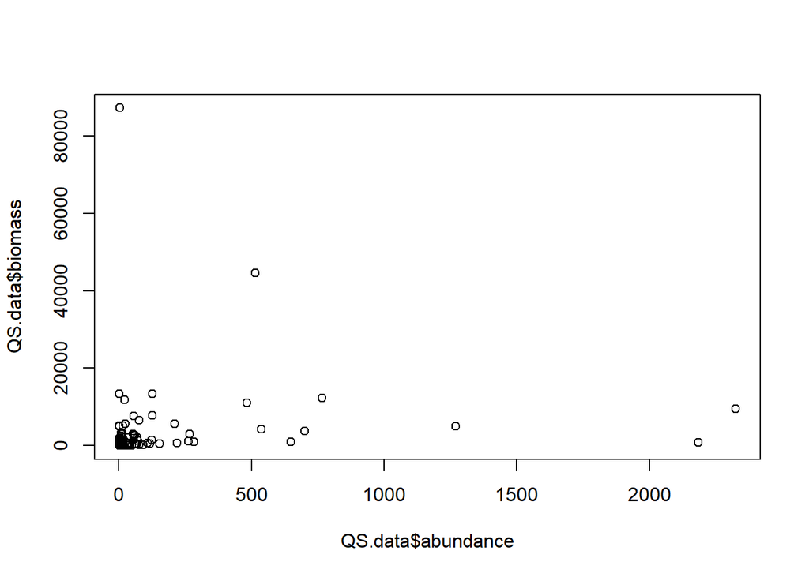

```r
QS.data <- QS[which(QS[,5]>0),c(2,4,5,7)]
QC.data <- QC[which(QC[,5]>0),c(2,4,5,7)]

##QS
plot(QS.data$abundance,QS.data$biomass)
```

```r
#fit model
fitQS <- lm(biomass~abundance,data=QS.data)
summary(fitQS)
```

```
##
## Call:
## lm(formula = biomass ~ abundance, data = QS.data)
##
## Residuals:
##    Min     1Q Median     3Q    Max
##  -9722  -1790  -1629   -863  85403
##
## Coefficients:
##             Estimate Std. Error t value Pr(>|t|)
## (Intercept) 1800.249    646.225   2.786  0.00599 **
## abundance      4.013      2.155   1.862  0.06439 .
## ---
## Signif. codes:  0 '***' 0.001 '**' 0.01 '*' 0.05 '.' 0.1 ' ' 1
##
## Residual standard error: 7906 on 160 degrees of freedom
## Multiple R-squared:  0.02122,    Adjusted R-squared:  0.0151
## F-statistic: 3.468 on 1 and 160 DF,  p-value: 0.06439
```

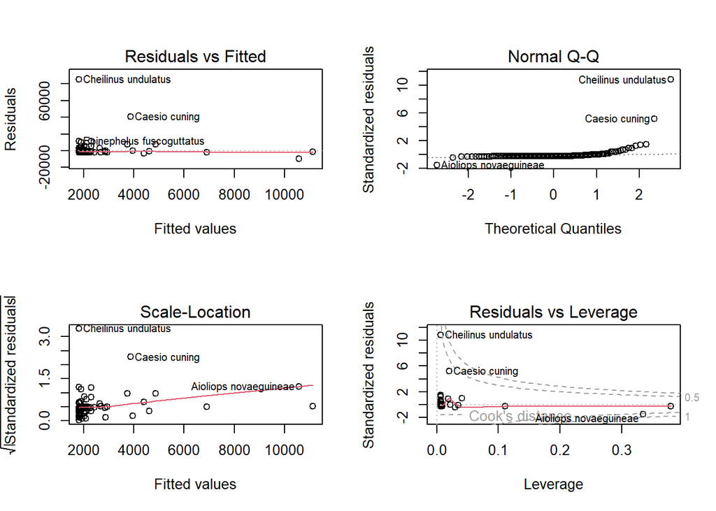

```r
par(mfrow=c(2,2))
plot(fitQS)
```

```r
QS.data.new <- QS.data[-which(rownames(QS.data)==c("Cheilinus undulatus","Caesio cuning")),]
fitQS.new <- lm(biomass~abundance,data=QS.data.new)
summary(fitQS.new)
```

```
##
## Call:
## lm(formula = biomass ~ abundance, data = QS.data.new)
##
## Residuals:
##     Min      1Q  Median      3Q     Max
## -7160.7 -1064.3  -883.4   -57.4 12229.0
##
## Coefficients:
##             Estimate Std. Error t value Pr(>|t|)
## (Intercept) 1079.597    200.024   5.397 2.43e-07 ***
## abundance      3.171      0.669   4.740 4.74e-06 ***
## ---
## Signif. codes:  0 '***' 0.001 '**' 0.01 '*' 0.05 '.' 0.1 ' ' 1
##
## Residual standard error: 2437 on 158 degrees of freedom
## Multiple R-squared:  0.1245, Adjusted R-squared:  0.1189
## F-statistic: 22.47 on 1 and 158 DF,  p-value: 4.738e-06
```

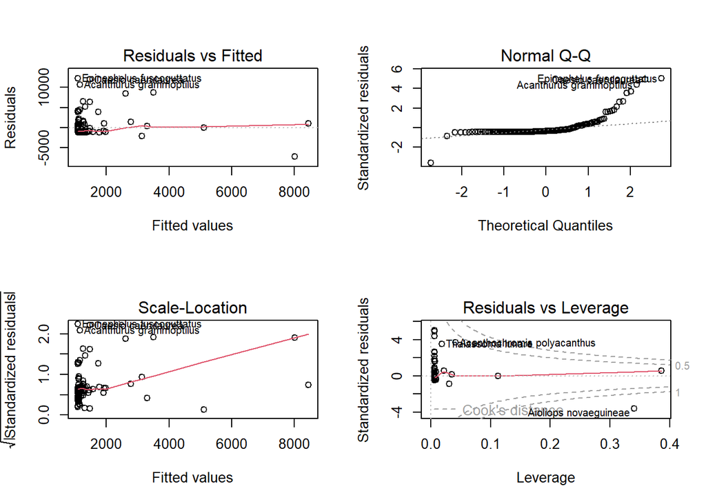

```r
par(mfrow=c(2,2))
plot(fitQS.new)
```

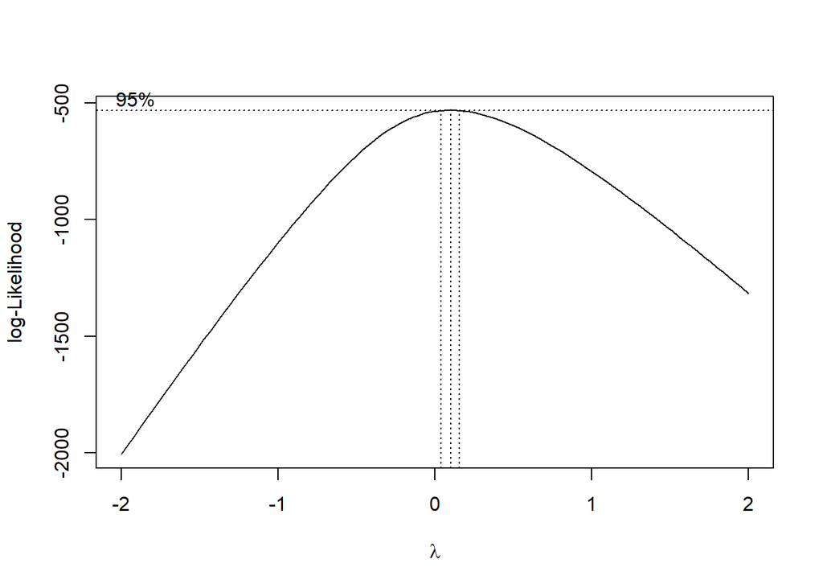

```r
par(mfrow=c(1,1))
#boxcox transform
boxcoxfit <- boxcox(fitQS.new,plotit=T)
```

```r
#lambda close to 0 => log transform
(lambda <- boxcoxfit$x[which.max(boxcoxfit$y)])
```

```
## [1] 0.1010101
```

```r
QS.data.new[,c(1,3)] <- log(QS.data.new[,c(1,3)])

#new fit model
fitQS2 <- lm(biomass~abundance,data=QS.data.new)
summary(fitQS2)
```

```
##
## Call:
## lm(formula = biomass ~ abundance, data = QS.data.new)
##
## Residuals:
##     Min      1Q  Median      3Q     Max
## -5.1991 -1.2950  0.1883  1.4037  5.4740
##
## Coefficients:
##             Estimate Std. Error t value Pr(>|t|)
## (Intercept)  4.02242    0.25086  16.034  < 2e-16 ***
## abundance    0.60929    0.08609   7.077 4.52e-11 ***
## ---
## Signif. codes:  0 '***' 0.001 '**' 0.01 '*' 0.05 '.' 0.1 ' ' 1
##
## Residual standard error: 2.051 on 158 degrees of freedom
## Multiple R-squared:  0.2407, Adjusted R-squared:  0.2359
## F-statistic: 50.09 on 1 and 158 DF,  p-value: 4.522e-11
```

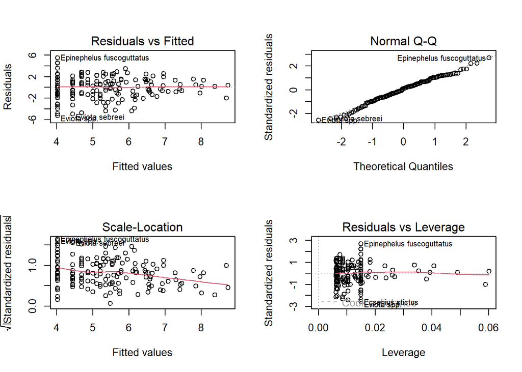

```r
par(mfrow=c(2,2))
plot(fitQS2)
```

```r
#confidence
confint(fitQS2,level=0.95)
```

```
##                 2.5 %    97.5 %
## (Intercept) 3.5269450 4.5178975
## abundance   0.4392543 0.7793293
```

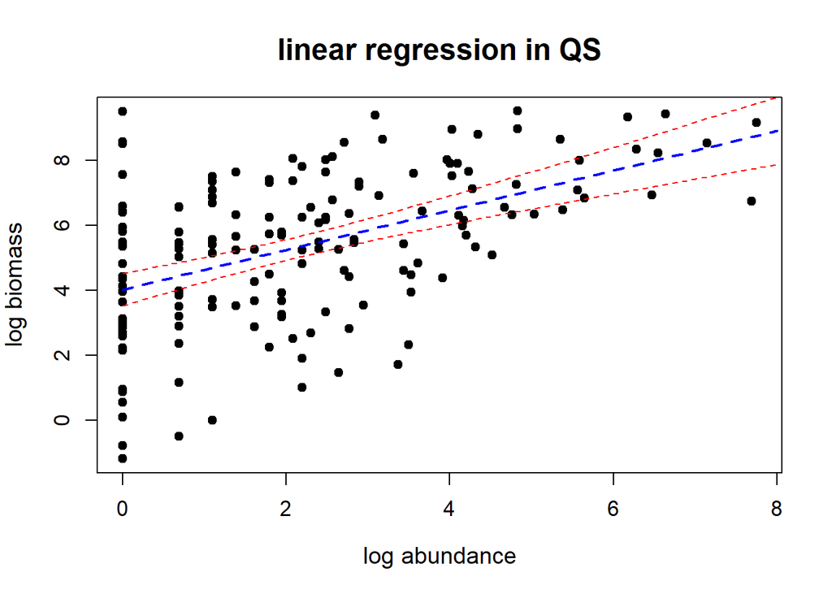

```r
pred <- data.frame(abundance=seq(0,8,0.1))
pred.band <- predict(fitQS2,pred,interval='confidence',level=0.95)

#plot regression plot
par(mfrow=c(1,1))
plot(biomass~abundance,data=QS.data.new,pch=19,cex.lab=1.2,cex.axis=1.1,cex.main=1.5,
     main="linear regression in QS",xlab="log abundance",ylab="log biomass")
lines(pred[,1],pred.band[,1],lty=2,lwd=2,col='blue')
lines(pred[,1],pred.band[,2],lty=2,col='red')
lines(pred[,1],pred.band[,3],lty=2,col='red')
```

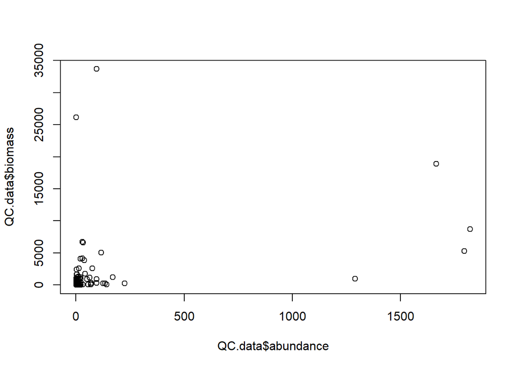

```r
#QC
plot(QC.data$abundance,QC.data$biomass)
```

```r
#fit model
fitQC <- lm(biomass~abundance,data=QC.data)
summary(fitQC)
```

```
##
## Call:
## lm(formula = biomass ~ abundance, data = QC.data)
##
## Residuals:
##    Min     1Q Median     3Q    Max
##  -6341  -1014   -910   -370  32198
##
## Coefficients:
##             Estimate Std. Error t value Pr(>|t|)
## (Intercept) 1010.274    382.130   2.644 0.009293 **
## abundance      4.903      1.261   3.887 0.000167 ***
## ---
## Signif. codes:  0 '***' 0.001 '**' 0.01 '*' 0.05 '.' 0.1 ' ' 1
##
## Residual standard error: 4095 on 120 degrees of freedom
## Multiple R-squared:  0.1118, Adjusted R-squared:  0.1044
## F-statistic: 15.11 on 1 and 120 DF,  p-value: 0.0001667
```

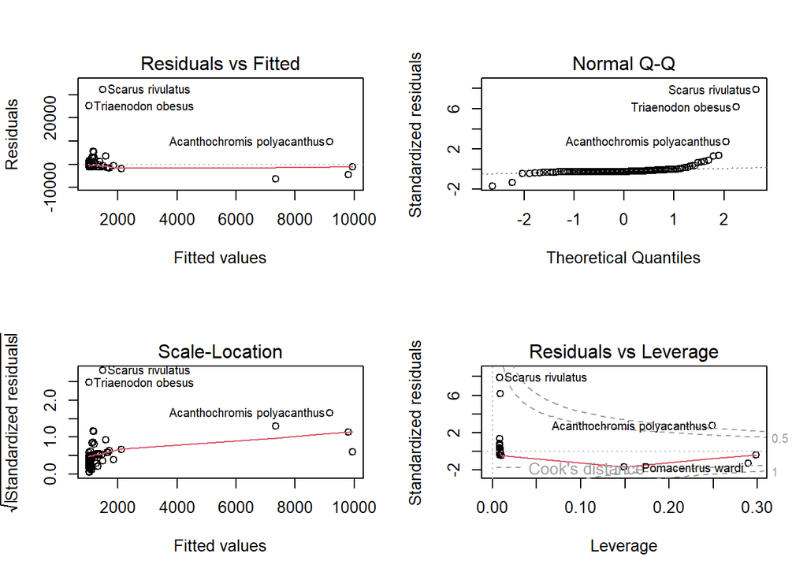

```r
par(mfrow=c(2,2))
plot(fitQC)
```

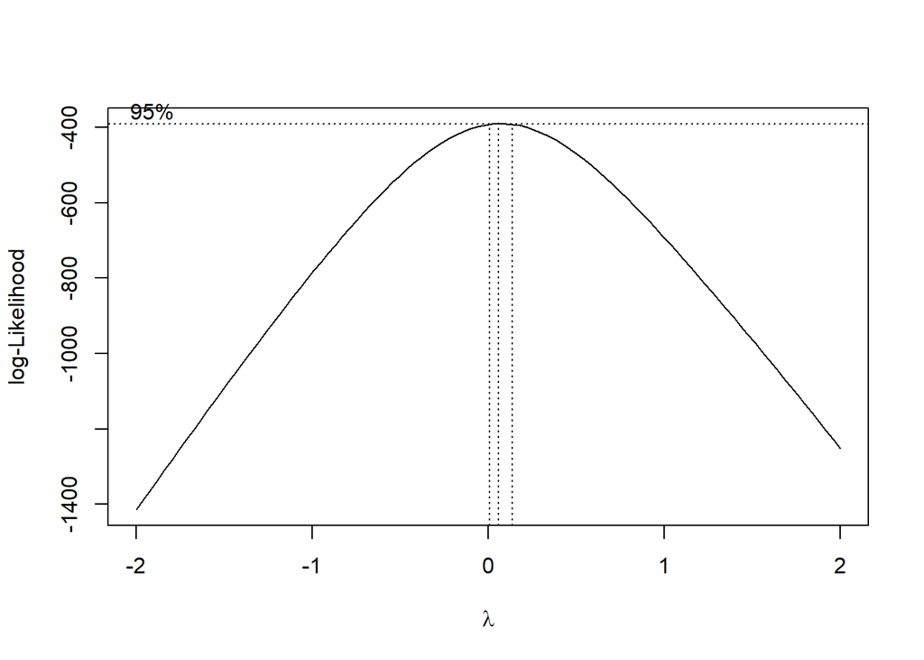

```r
par(mfrow=c(1,1))
#boxcox transform
boxcoxfit2 <- boxcox(fitQC,plotit=T)
```

```r
#lambda close to 0 => log transform
(lambda <- boxcoxfit2$x[which.max(boxcoxfit2$y)])
```

```
## [1] 0.06060606
```

```r
QC.data[,c(1,3)] <- log(QC.data[,c(1,3)])

#new fit model
fitQC2 <- lm(biomass~abundance,data=QC.data)
summary(fitQC2)
```

```
##
## Call:
## lm(formula = biomass ~ abundance, data = QC.data)
##
## Residuals:
##     Min      1Q  Median      3Q     Max
## -4.7247 -1.4400  0.4325  1.4101  6.3938
##
## Coefficients:
##             Estimate Std. Error t value Pr(>|t|)
## (Intercept)   3.7777     0.2774  13.620  < 2e-16 ***
## abundance     0.6447     0.1042   6.184 8.91e-09 ***
## ---
## Signif. codes:  0 '***' 0.001 '**' 0.01 '*' 0.05 '.' 0.1 ' ' 1
##
## Residual standard error: 2.082 on 120 degrees of freedom
## Multiple R-squared:  0.2417, Adjusted R-squared:  0.2354
## F-statistic: 38.25 on 1 and 120 DF,  p-value: 8.911e-09
```

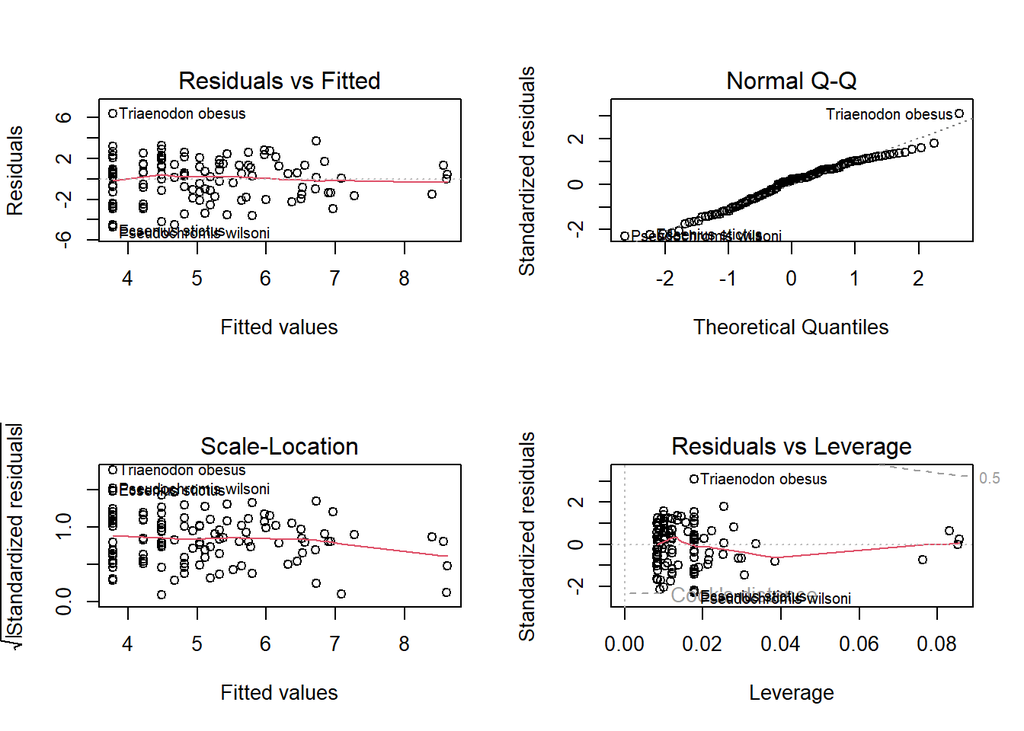

```r
par(mfrow=c(2,2))
plot(fitQC2)
```

```r
#confidence
confint(fitQC2,level=0.95)
```

```
##                 2.5 %    97.5 %
## (Intercept) 3.2285269 4.3268276
## abundance   0.4382832 0.8510613
```

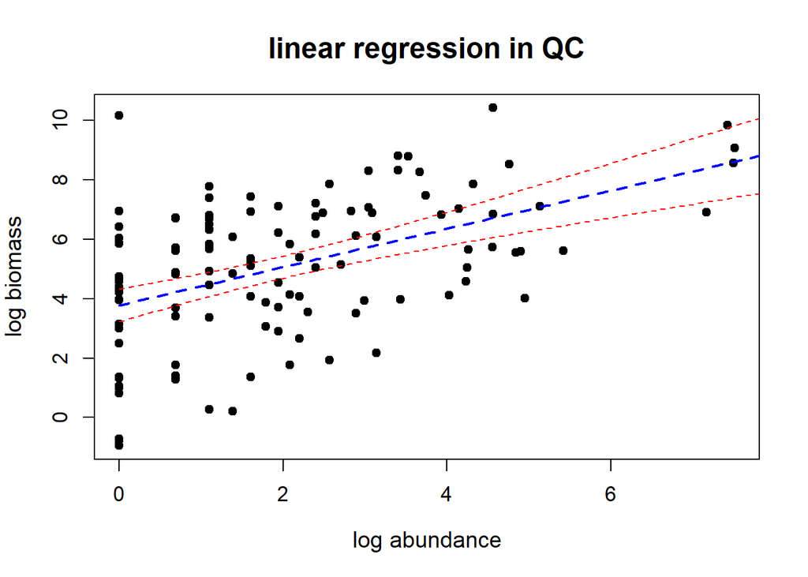

```r
pred2 <- data.frame(abundance=seq(0,7.8,0.1))
pred.band2 <- predict(fitQC2,pred2,interval='confidence',level=0.95)

#plot
par(mfrow=c(1,1))
plot(biomass~abundance,data=QC.data,pch=19,cex.lab=1.2,cex.axis=1.1,cex.main=1.5,
     main="linear regression in QC",xlab="log abundance",ylab="log biomass")
lines(pred2[,1],pred.band2[,1],lty=2,lwd=2,col='blue')
lines(pred2[,1],pred.band2[,2],lty=2,col='red')
lines(pred2[,1],pred.band2[,3],lty=2,col='red')
```

### ref:

#### (1): Gust, N., Choat, J. H., & McCormick, M. I. (2001). Spatial variability in reef fish distribution, abundance, size and biomass: a multi scale analysis. Marine Ecology Progress Series, 214, 237-251.

#### (2): Aburto‐Oropeza, O., & Balart, E. F. (2001). Community structure of reef fish in several habitats of a rocky reef in the Gulf of California. Marine ecology, 22(4), 283-305.

#### (3): Medina, M., Estes, C., Best, B., Stallings, C. D., Montes, E., McEachron, L. G., & Muller-Karger, F. E. (2021). REEF-FISH ABUNDANCE, BIOMASS, AND BIODIVERSITY. Oceanography, 34(2), 52-61.